# Exploratory and Confirmatory Factor Anaysis

## Factor Extraction (PCA)

For our purposes we will use principal components analysis (PCA) to extract interrelated factors from the data. Principal component analysis is carried out using the principal() function in the psych package.

```r
pc1 <- principal(anxiety.cor, nfactors=23, rotate="none")
as.matrix(pc1$loadings)
```

[output not shown]

When we call the loading from this analysis, we have the loading matrix for each of the extracted factors. Because we have requested all possible factors here, the loading are unimportant for now. What is important is the SS loading (which means sum of squares or variance explained) by the extracted factors (listed PC for principal components). The critical value we are looking for here is 1 (Kaiser’s stopping rule). As we can see, 4 factors have SS loading above one. This suggests that four factors best explain the interrelationships between items in our data. We can also inspect the scree plot:

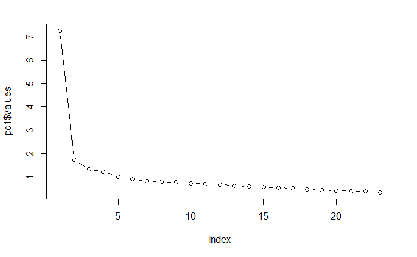

```r
plot(pc1$values, type="b")
```

From the scree plot, we could find the point of inflection (around the third point to the left). The evidence from the scree plot and from the sum of squares loadings suggests a four-component solution may be the best.

## Redo PCA

Now that we know how many factors we want to extract, we can rerun the analysis, specifying that number. To do this, we use an identical command to the previous model but we change nfactors = 23 to be nfactors = 4 because we now want only four factors.

```r
pc2 <- principal(anxiety.cor, nfactors=4, rotate="none")
as.matrix(pc2$loadings)
```

[output not shown]

Now we are getting somewhere. We can see the factor loadings are more informative here. They reflect the correlation between the item and the factor. The SS loadings are as they were before but now we can interpret the proportion and cumulative variance rows, too. Here we see the variance explained by the factors. PC1 explains 32% of the item variance, PC2 explains 8% of the item variance, and so on. The cumulative variance is the overall variance from one factor to the next to the next.

You will see that most items correlate with the first factor. Some items with the second, less with the third and even less with the fourth. This is to be expected given how PCA extracts factors without rotation. We can rotate the four factors into new positions and therefore optimize the loadings. Lets do that now using varimax rotation.

## Rotation

To rotate the factors we can set rotate=“varimax” in the principal() function. There are many possible solutions and the varimax rotation optimizes for maximum variance explained. The print.psych() command prints the factor loading matrix associated with the rotated model, but displaying only loadings above .3 (cut = 0.3, because anything below is too low) and sorting items by the size of their loadings (sort = TRUE).

```r
pc3 <- principal(anxiety.cor, nfactors=4, rotate="varimax")
print.psych(pc3, cut = 0.3, sort = TRUE)
```

```
Principal Components Analysis
Call: principal(r = anxiety.cor, nfactors = 4, rotate = "varimax")
Standardized loadings (pattern matrix) based upon correlation matrix
```

|  | item | RC3 | RC1 | RC4 | RC2 | h2 | u2 | com |
| --- | --- | --- | --- | --- | --- | --- | --- | --- |
| Q06 | 6 | 0.80 |  |  |  | 0.6539317 | 0.3460683 | 1.045955 |
| Q18 | 18 | 0.68 | 0.33 |  |  | 0.5973378 | 0.4026622 | 1.549751 |
| Q13 | 13 | 0.65 |  |  |  | 0.5358284 | 0.4641716 | 1.583842 |
| Q07 | 7 | 0.64 | 0.33 |  |  | 0.5452943 | 0.4547057 | 1.672163 |
| Q14 | 14 | 0.58 | 0.36 |  |  | 0.4882649 | 0.5117351 | 1.845703 |
| Q10 | 10 | 0.55 |  |  |  | 0.3347726 | 0.6652274 | 1.215135 |
| Q15 | 15 | 0.46 |  |  |  | 0.3779918 | 0.6220082 | 2.597228 |
| Q20 | 20 |  | 0.68 |  |  | 0.4839965 | 0.5160035 | 1.115164 |
| Q21 | 21 |  | 0.66 |  |  | 0.5499069 | 0.4500931 | 1.526199 |
| Q03 | 3 |  | 0.57 |  | -0.37 | 0.5297160 | 0.4702840 | 2.261522 |

[output cut: 13 more lines]

```
                       RC3  RC1  RC4  RC2
SS loadings           3.73 3.34 2.55 1.95
Proportion Var        0.16 0.15 0.11 0.08
Cumulative Var        0.16 0.31 0.42 0.50
Proportion Explained  0.32 0.29 0.22 0.17
Cumulative Proportion 0.32 0.61 0.83 1.00

Mean item complexity =  1.8
Test of the hypothesis that 4 components are sufficient.

The root mean square of the residuals (RMSR) is  0.06
 with the empirical chi square  4006.15  with prob <  0

Fit based upon off diagonal values = 0.96
```

h2 is the commonality, u2 is the error for each item. The factors loadings, again, are the correlations between the item and its factor.

According to the results and the questionnaires above, we could find the questions that load highly on factor 1 are Q6 (“I have little experience of computers”) with the highest loading of .80, Q18 (“R always crashes when I try to use it”), Q13 (“I worry I will cause irreparable damage …”), Q7 (“All computers hate me”), Q14 (“Computers have minds of their own …”), Q10 (“Computers are only for games”), and Q15 (“Computers are out to get me”) with the lowest loading of .46. All these items seem to relate to using computers or R. Therefore, we might label this factor fear of computers.

Similarly, we might label the factor 2 as fear of statistics, factor 3 fear of mathematics, and factor 4 peer evaluation.

## Reliability Analysis

If you’re using factor analysis to validate a questionnaire, like we are here, as we saw last year it is useful to check the reliability of your scale.

Reliability means that a measure (or in this case questionnaire) should consistently reflect the construct that it is measuring. One way to think of this is that, other things being equal, a person should get the same score on a questionnaire if they complete it at two different points in time.

The simplest way to do this is with Cronbach’s alpha. Thinking back to last year, Cronbach’s alpha is loosely equivalent to splitting data in two in every possible way and computing the correlation coefficient for each split, and then compute the average of these values.

Recall that we have four factors: fear of computers, fear of statistics, fear of mathematics, and peer evaluation. Each factor stands for several questions in the questionnaire. For example, fear of computers includes question 6, 7, 10, …, 18.

```r
computerFear<-anxiety.cor[, c(6, 7, 10, 13, 14, 15, 18)]
statisticsFear <- anxiety.cor[, c(1, 3, 4, 5, 12, 16, 20, 21)]
mathFear <- anxiety.cor[, c(8, 11, 17)]
peerEvaluation <- anxiety.cor[, c(2, 9, 19, 22, 23)]
```

Reliability analysis is done with the alpha() function, which is found in the psych package.

```r
psych::alpha(computerFear)
```

|  | raw_alpha | std.alpha | G6(smc) | average_r | S/N | ase | mean | sd | median_r |
| --- | --- | --- | --- | --- | --- | --- | --- | --- | --- |
|  | 0.8233595 | 0.8214131 | 0.8051715 | 0.3965265 | 4.599515 | 0.005216248 | 3.415403 | 0.7099879 | 0.3913668 |

```
 lower alpha upper     95% confidence boundaries
0.81 0.82 0.83

 Reliability if an item is dropped:
```

|  | raw_alpha | std.alpha | G6(smc) | average_r | S/N | alpha se | var.r | med.r |
| --- | --- | --- | --- | --- | --- | --- | --- | --- |
| Q06 | 0.7905934 | 0.7885424 | 0.7651928 | 0.3832922 | 3.729080 | 0.006290270 | 0.008077541 | 0.3801148 |
| Q07 | 0.7904747 | 0.7887922 | 0.7657251 | 0.3836465 | 3.734673 | 0.006293846 | 0.007926764 | 0.3598931 |
| Q10 | 0.8239024 | 0.8240881 | 0.8011692 | 0.4384474 | 4.684663 | 0.005342093 | 0.004291948 | 0.4421193 |
| Q13 | 0.7936766 | 0.7905203 | 0.7677567 | 0.3861097 | 3.773733 | 0.006167027 | 0.008064726 | 0.3801148 |
| Q14 | 0.7979749 | 0.7955608 | 0.7730056 | 0.3934144 | 3.891431 | 0.006035109 | 0.008508588 | 0.3598931 |
| Q15 | 0.8118706 | 0.8093487 | 0.7875040 | 0.4143587 | 4.245179 | 0.005603716 | 0.009452473 | 0.4421193 |
| Q18 | 0.7855331 | 0.7836346 | 0.7578478 | 0.3764168 | 3.621811 | 0.006427460 | 0.005826593 | 0.3801148 |

```
 Item statistics
```

|  | n | raw.r | std.r | r.cor | r.drop | mean | sd |
| --- | --- | --- | --- | --- | --- | --- | --- |
| Q06 | 2571 | 0.7482507 | 0.7356097 | 0.6818773 | 0.6187265 | 3.772851 | 1.1220023 |
| Q07 | 2571 | 0.7463776 | 0.7345169 | 0.6799128 | 0.6190323 | 3.076235 | 1.1023600 |
| Q10 | 2571 | 0.5429157 | 0.5655016 | 0.4392362 | 0.3999218 | 3.719175 | 0.8771293 |
| Q13 | 2571 | 0.7203114 | 0.7269201 | 0.6690493 | 0.6067436 | 3.550758 | 0.9485040 |
| Q14 | 2571 | 0.7030734 | 0.7043912 | 0.6361547 | 0.5768249 | 3.123687 | 0.9985724 |
| Q15 | 2571 | 0.6376030 | 0.6397954 | 0.5410779 | 0.4912675 | 3.233761 | 1.0093935 |
| Q18 | 2571 | 0.7619867 | 0.7568146 | 0.7168204 | 0.6473895 | 3.431350 | 1.0531837 |

```
Non missing response frequency for each item
       1    2    3    4    5 miss
Q06 0.06 0.10 0.13 0.44 0.27    0
Q07 0.09 0.24 0.26 0.34 0.07    0
Q10 0.02 0.10 0.18 0.57 0.14    0
Q13 0.03 0.12 0.25 0.48 0.12    0
Q14 0.07 0.18 0.38 0.31 0.06    0
Q15 0.06 0.18 0.30 0.39 0.07    0
Q18 0.06 0.12 0.31 0.37 0.14    0
```

```r
psych::alpha(statisticsFear)
```

```
Reliability analysis
Call: psych::alpha(x = statisticsFear)
```

|  | raw_alpha | std.alpha | G6(smc) | average_r | S/N | ase | mean | sd | median_r |
| --- | --- | --- | --- | --- | --- | --- | --- | --- | --- |
|  | 0.8208362 | 0.823419 | 0.8130458 | 0.3682444 | 4.663125 | 0.005340665 | 2.983615 | 0.6402936 | 0.3977951 |

```
 lower alpha upper     95% confidence boundaries
0.81 0.82 0.83

 Reliability if an item is dropped:
```

|  | raw_alpha | std.alpha | G6(smc) | average_r | S/N | alpha se | var.r | med.r |
| --- | --- | --- | --- | --- | --- | --- | --- | --- |
| Q01 | 0.8017011 | 0.8036664 | 0.7865897 | 0.3689926 | 4.093371 | 0.005976741 | 0.005198651 | 0.4006722 |
| Q03 | 0.7995999 | 0.8024997 | 0.7892585 | 0.3672764 | 4.063283 | 0.006057134 | 0.007025582 | 0.4006722 |
| Q04 | 0.7955019 | 0.7982387 | 0.7835596 | 0.3611012 | 3.956352 | 0.006152502 | 0.006081017 | 0.3467432 |
| Q05 | 0.8066453 | 0.8091530 | 0.7950800 | 0.3772132 | 4.239801 | 0.005814927 | 0.005780319 | 0.4099513 |
| Q12 | 0.7962349 | 0.7994735 | 0.7857475 | 0.3628760 | 3.986873 | 0.006143718 | 0.006656044 | 0.3949180 |
| Q16 | 0.7927741 | 0.7950846 | 0.7791306 | 0.3566214 | 3.880064 | 0.006230884 | 0.005664515 | 0.3467432 |
| Q20 | 0.8184545 | 0.8205820 | 0.8015457 | 0.3951740 | 4.573576 | 0.005460366 | 0.002154054 | 0.4080591 |
| Q21 | 0.7908068 | 0.7951407 | 0.7769896 | 0.3567004 | 3.881400 | 0.006303653 | 0.006305289 | 0.3804602 |

```
 Item statistics
```

|  | n | raw.r | std.r | r.cor | r.drop | mean | sd |
| --- | --- | --- | --- | --- | --- | --- | --- |
| Q01 | 2571 | 0.6462951 | 0.6658037 | 0.6022979 | 0.5361233 | 3.625827 | 0.8280221 |
| Q03 | 2571 | 0.6872769 | 0.6725401 | 0.6026929 | 0.5492298 | 2.585375 | 1.0750097 |
| Q04 | 2571 | 0.6923218 | 0.6967796 | 0.6391122 | 0.5750069 | 3.213925 | 0.9485482 |
| Q05 | 2571 | 0.6300660 | 0.6335355 | 0.5517860 | 0.4944489 | 3.277713 | 0.9646904 |
| Q12 | 2571 | 0.6858128 | 0.6898128 | 0.6275878 | 0.5715319 | 2.840529 | 0.9164763 |
| Q16 | 2571 | 0.7061457 | 0.7143640 | 0.6655091 | 0.5972863 | 3.120576 | 0.9160526 |
| Q20 | 2571 | 0.5781867 | 0.5630341 | 0.4677132 | 0.4185194 | 2.375729 | 1.0357511 |
| Q21 | 2571 | 0.7206118 | 0.7140540 | 0.6672768 | 0.6061264 | 2.829249 | 0.9847160 |

```
Non missing response frequency for each item
       1    2    3    4    5 miss
Q01 0.02 0.07 0.29 0.52 0.11    0
Q03 0.19 0.26 0.34 0.17 0.03    0
Q04 0.05 0.17 0.36 0.37 0.05    0
Q05 0.04 0.18 0.29 0.43 0.06    0
Q12 0.09 0.23 0.46 0.20 0.02    0
Q16 0.06 0.16 0.42 0.33 0.04    0
Q20 0.22 0.37 0.25 0.15 0.02    0
Q21 0.09 0.29 0.34 0.26 0.02    0
```

```r
psych::alpha(mathFear)
```

```
Reliability analysis
Call: psych::alpha(x = mathFear)
```

|  | raw_alpha | std.alpha | G6(smc) | average_r | S/N | ase | mean | sd | median_r |
| --- | --- | --- | --- | --- | --- | --- | --- | --- | --- |
|  | 0.8194092 | 0.8194754 | 0.7524072 | 0.602091 | 4.539411 | 0.006174216 | 3.68041 | 0.7534222 | 0.5901402 |

```
 lower alpha upper     95% confidence boundaries
0.81 0.82 0.83

 Reliability if an item is dropped:
```

|  | raw_alpha | std.alpha | G6(smc) | average_r | S/N | alpha se | var.r | med.r |
| --- | --- | --- | --- | --- | --- | --- | --- | --- |
| Q08 | 0.7396261 | 0.7396295 | 0.5868350 | 0.5868350 | 2.840681 | 0.010270028 | NA | 0.5868350 |
| Q11 | 0.7422104 | 0.7422493 | 0.5901402 | 0.5901402 | 2.879718 | 0.010166907 | NA | 0.5901402 |
| Q17 | 0.7724577 | 0.7724772 | 0.6292977 | 0.6292977 | 3.395165 | 0.008974525 | NA | 0.6292977 |

```
 Item statistics
```

|  | n | raw.r | std.r | r.cor | r.drop | mean | sd |
| --- | --- | --- | --- | --- | --- | --- | --- |
| Q08 | 2571 | 0.8619847 | 0.8630951 | 0.7575933 | 0.6844661 | 3.763127 | 0.8725704 |
| Q11 | 2571 | 0.8619980 | 0.8618098 | 0.7546943 | 0.6817860 | 3.744846 | 0.8805329 |
| Q17 | 2571 | 0.8474976 | 0.8465822 | 0.7182565 | 0.6519969 | 3.533256 | 0.8839042 |

```
Non missing response frequency for each item
       1    2    3    4    5 miss
Q08 0.03 0.06 0.19 0.58 0.15    0
Q11 0.02 0.06 0.22 0.53 0.16    0
Q17 0.03 0.10 0.27 0.52 0.08    0
```

```r
psych::alpha(peerEvaluation)
```

```
Reliability analysis
Call: psych::alpha(x = peerEvaluation)
```

|  | raw_alpha | std.alpha | G6(smc) | average_r | S/N | ase | mean | sd | median_r |
| --- | --- | --- | --- | --- | --- | --- | --- | --- | --- |
|  | 0.5699185 | 0.5724418 | 0.5251714 | 0.211215 | 1.338863 | 0.01319737 | 3.383119 | 0.6476619 | 0.2306221 |

```
 lower alpha upper     95% confidence boundaries
0.54 0.57 0.6

 Reliability if an item is dropped:
```

|  | raw_alpha | std.alpha | G6(smc) | average_r | S/N | alpha se | var.r | med.r |
| --- | --- | --- | --- | --- | --- | --- | --- | --- |
| Q02 | 0.5152809 | 0.5162544 | 0.4493171 | 0.2106098 | 1.0672024 | 0.01548367 | 0.002786266 | 0.2321460 |
| Q09 | 0.4764817 | 0.4787905 | 0.4144561 | 0.1867628 | 0.9186144 | 0.01672660 | 0.003613341 | 0.2168334 |
| Q19 | 0.5218165 | 0.5260314 | 0.4640472 | 0.2171973 | 1.1098443 | 0.01508233 | 0.005478721 | 0.2306221 |
| Q22 | 0.4870476 | 0.4894880 | 0.4286288 | 0.1933561 | 0.9588179 | 0.01612513 | 0.006451026 | 0.1870359 |
| Q23 | 0.5628296 | 0.5690031 | 0.5000617 | 0.2481489 | 1.3202024 | 0.01380181 | 0.001402113 | 0.2416171 |

```
 Item statistics
```

|  | n | raw.r | std.r | r.cor | r.drop | mean | sd |
| --- | --- | --- | --- | --- | --- | --- | --- |
| Q02 | 2571 | 0.5610145 | 0.6086262 | 0.4462654 | 0.3389092 | 4.376507 | 0.8510787 |
| Q09 | 2571 | 0.6951297 | 0.6557367 | 0.5265555 | 0.3906534 | 3.153637 | 1.2631123 |
| Q19 | 2571 | 0.6054323 | 0.5956124 | 0.4157075 | 0.3162461 | 3.707896 | 1.1014016 |
| Q22 | 2571 | 0.6360598 | 0.6427114 | 0.4979942 | 0.3776059 | 3.112019 | 1.0407530 |
| Q23 | 2571 | 0.5307961 | 0.5344664 | 0.3144633 | 0.2388815 | 2.565539 | 1.0437337 |

```
Non missing response frequency for each item
       1    2    3    4    5 miss
Q02 0.01 0.04 0.08 0.31 0.56    0
Q09 0.08 0.28 0.23 0.20 0.20    0
Q19 0.02 0.15 0.22 0.33 0.29    0
Q22 0.05 0.26 0.34 0.26 0.10    0
Q23 0.12 0.42 0.27 0.12 0.06    0
```

Great, we have successfully conducted exploratory factor analysis and have reduced our questionnaire to four factors. Pretty neat.

# Confirmatory Factor Analysis (CFA)

We have just conducted EFA to find the most optimal underlying factor solution for our questionnaire items. That’s great. But lets say we collected data again on this questionnaire. We now know that it has a four factor solution. How then do we check the measurement model to ensure that this four factor solution is good in our new dataset?

Well, when we know the theoretical factor structure of a set of items, we can *confirm* its factor structure using something called confirmatory factor analysis.

Confirmatory factor analysis (CFA) is a type of structural equation model, just like path analysis. But in this case we use latent variables, or factors, rather than measured (or averaged) variables.

## Latent Variables in CFA

CFA, like EFA, uses the concept of a latent variable which is the cause of items we measure. So for instance, the items 8, 11, and 17 for the anxiety questionnaire are caused by an unobserved, latent, Math Fear variable. This is the process that we think is generating the data: items 8, 11, and 17 belong to Math Fear and should correlate more strongly with each other than they do with the rest of the items we have measured.

CFA provides a mechanism to test these hypothesized patterns, which correspond to different models of the underlying process which generates the data.

It is conventional within CFA to extend the graphical models used to describe path models that we looked at last week. In these diagrams, square edged boxes represent observed variables, and rounded or oval boxes represent latent variables, sometimes called factors:

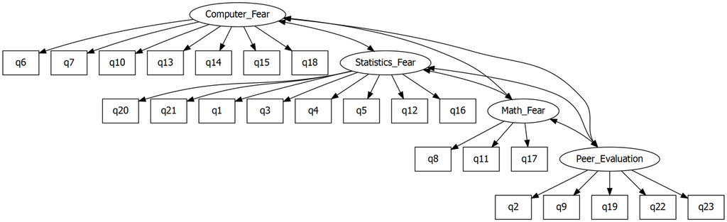

CFA For Anxiety Data

You can see here that I have constructed what is called a measurement model for the items in the anxiety questionnaire. This model is based on the factor analysis we just conducted. CFA is simply the way we test whether this model is a good fit to the data, does this factor structure correspond with the correlations between the items?

Now hopefully you are beginning to see the symmetry between path analysis and CFA in terms of the structural equation model. When we say how well the model fit, what we are saying is does the covariance matrix for the model approximate the covariance matrix for the data. Just like we did last week. The principal is exactly the same!

Only this time, we are testing a model with latent variables, which capture the common variances among the items. If the model fits well, that is to say the covariance matrices are more or less the same, then that is good evidence that the items indeed belong in their latent variable clusters. If the model does not fit well - there is a problem with our measurement.

There is an important advantage of modeling variables this way: latent variables are measured without error. They contain the common variance of the items therefore do not contain any unique or error variance. We have solved the problem of imperfect measurement!

## Building a CFA model

To define our CFA model for the anxiety data we are going to use lavaan. As noted last week, to define models in lavaan you must specify the relationships between variables in a text format. A full guide to this lavaan model syntax is available on the lavaan project website.

For CFA models, like path models, the format is fairly simple, and resembles a series of linear models, written over several lines.

In the model below there are four latent variables, computer fear, statistics fear, math fear, and peer evaluation. The latent variable names are followed by =~ which means ‘is manifested by’, and then the observed variables, our items for the latent variable, are listed, separated by the + symbol.

```r
cfa.model <- "
computerFear =~ 1*Q06 + Q07 + Q10 + Q13 + Q14 + Q15 + Q18
statisticsFear=~ 1*Q01 + Q03 + Q04 + Q05 + Q12 + Q16 + Q20 + Q21
mathFear =~ 1*Q08 + Q11 + Q17
peerEvaluation =~ 1*Q02 + Q09 + Q19 + Q22 + Q23
"
```

Note that we have saved our model specification in a variable named cfa.model. Just like last week for path analysis.

The special symbols in the lavaan syntax used for latent varianbles in CFA models is =~ where the latent variable is listed before and the items listed after.

Also note that "*" fixes variables to a particular value. Here we adopt whats called the marker variable identification approach, where we fix the loading of one indicator in each latent to 1 in order to identify the model and give each latent factor a metric.

This will not change model fit, just some of the loadings in the model. Fixing to 1 makes it so that a one unit change in the latent factor is interpreted as a unit unit change in the scale of the item selected as the marker variable (the variable loading we fix to 1). Thats all I am doing here by setting the first item to 1*.